# Risk Factor Analysis

## Outcome Variable

**Outcome Variable:** stunted

## Predictor Variables

**Intervention Variable:** single

**Adjustment Set:**

- arm
- W_mage
- W_fage
- meducyrs
- feducyrs
- W_mhtcm
- W_mwtkg
- W_mbmi
- delta_W_mage
- delta_W_fage
- delta_meducyrs
- delta_feducyrs
- delta_W_mhtcm
- delta_W_mwtkg
- delta_W_mbmi

## Stratifying Variables

The analysis was stratified on these variable(s):

- agecat
- studyid
- country

## Data Summary

| agecat | studyid | country | single | stunted | n_cell | n |
| --- | --- | --- | --- | --- | --- | --- |
| Birth | ki0047075b-MAL-ED | BANGLADESH | 0 | 0 | 210 | 257 |
| Birth | ki0047075b-MAL-ED | BANGLADESH | 0 | 1 | 47 | 257 |
| 6 months | ki0047075b-MAL-ED | BANGLADESH | 0 | 0 | 196 | 241 |
| 6 months | ki0047075b-MAL-ED | BANGLADESH | 0 | 1 | 45 | 241 |
| 24 months | ki0047075b-MAL-ED | BANGLADESH | 0 | 0 | 114 | 212 |
| 24 months | ki0047075b-MAL-ED | BANGLADESH | 0 | 1 | 98 | 212 |
| Birth | ki0047075b-MAL-ED | BRAZIL | 0 | 0 | 151 | 191 |
| Birth | ki0047075b-MAL-ED | BRAZIL | 0 | 1 | 15 | 191 |
| Birth | ki0047075b-MAL-ED | BRAZIL | 1 | 0 | 19 | 191 |
| Birth | ki0047075b-MAL-ED | BRAZIL | 1 | 1 | 6 | 191 |
| 6 months | ki0047075b-MAL-ED | BRAZIL | 0 | 0 | 175 | 209 |
| 6 months | ki0047075b-MAL-ED | BRAZIL | 0 | 1 | 4 | 209 |
| 6 months | ki0047075b-MAL-ED | BRAZIL | 1 | 0 | 28 | 209 |
| 6 months | ki0047075b-MAL-ED | BRAZIL | 1 | 1 | 2 | 209 |
| 24 months | ki0047075b-MAL-ED | BRAZIL | 0 | 0 | 145 | 169 |
| 24 months | ki0047075b-MAL-ED | BRAZIL | 0 | 1 | 3 | 169 |
| 24 months | ki0047075b-MAL-ED | BRAZIL | 1 | 0 | 18 | 169 |
| 24 months | ki0047075b-MAL-ED | BRAZIL | 1 | 1 | 3 | 169 |
| Birth | ki0047075b-MAL-ED | INDIA | 0 | 0 | 173 | 205 |
| Birth | ki0047075b-MAL-ED | INDIA | 0 | 1 | 32 | 205 |
| 6 months | ki0047075b-MAL-ED | INDIA | 0 | 0 | 190 | 234 |
| 6 months | ki0047075b-MAL-ED | INDIA | 0 | 1 | 44 | 234 |
| 24 months | ki0047075b-MAL-ED | INDIA | 0 | 0 | 131 | 225 |
| 24 months | ki0047075b-MAL-ED | INDIA | 0 | 1 | 94 | 225 |
| 6 months | ki0047075b-MAL-ED | NEPAL | 0 | 0 | 224 | 236 |
| 6 months | ki0047075b-MAL-ED | NEPAL | 0 | 1 | 12 | 236 |
| 24 months | ki0047075b-MAL-ED | NEPAL | 0 | 0 | 179 | 228 |
| 24 months | ki0047075b-MAL-ED | NEPAL | 0 | 1 | 49 | 228 |
| Birth | ki0047075b-MAL-ED | NEPAL | 0 | 0 | 155 | 173 |
| Birth | ki0047075b-MAL-ED | NEPAL | 0 | 1 | 18 | 173 |

[output cut: 106 more lines]

The following strata were considered:

- agecat: 24 months, studyid: ki0047075b-MAL-ED, country: BANGLADESH
- agecat: 24 months, studyid: ki0047075b-MAL-ED, country: BRAZIL
- agecat: 24 months, studyid: ki0047075b-MAL-ED, country: INDIA
- agecat: 24 months, studyid: ki0047075b-MAL-ED, country: NEPAL
- agecat: 24 months, studyid: ki0047075b-MAL-ED, country: PERU
- agecat: 24 months, studyid: ki0047075b-MAL-ED, country: SOUTH AFRICA
- agecat: 24 months, studyid: ki0047075b-MAL-ED, country: TANZANIA, UNITED REPUBLIC OF
- agecat: 24 months, studyid: ki1066203-TanzaniaChild2, country: TANZANIA, UNITED REPUBLIC OF
- agecat: 24 months, studyid: ki1119695-PROBIT, country: BELARUS
- agecat: 24 months, studyid: ki1126311-ZVITAMBO, country: ZIMBABWE
- agecat: 24 months, studyid: ki1135781-COHORTS, country: GUATEMALA
- agecat: 24 months, studyid: ki1135781-COHORTS, country: INDIA
- agecat: 24 months, studyid: ki1135781-COHORTS, country: PHILIPPINES
- agecat: 6 months, studyid: ki0047075b-MAL-ED, country: BANGLADESH
- agecat: 6 months, studyid: ki0047075b-MAL-ED, country: BRAZIL
- agecat: 6 months, studyid: ki0047075b-MAL-ED, country: INDIA
- agecat: 6 months, studyid: ki0047075b-MAL-ED, country: NEPAL
- agecat: 6 months, studyid: ki0047075b-MAL-ED, country: PERU
- agecat: 6 months, studyid: ki0047075b-MAL-ED, country: SOUTH AFRICA
- agecat: 6 months, studyid: ki0047075b-MAL-ED, country: TANZANIA, UNITED REPUBLIC OF
- agecat: 6 months, studyid: ki1066203-TanzaniaChild2, country: TANZANIA, UNITED REPUBLIC OF
- agecat: 6 months, studyid: ki1112895-Guatemala BSC, country: GUATEMALA
- agecat: 6 months, studyid: ki1119695-PROBIT, country: BELARUS
- agecat: 6 months, studyid: ki1126311-ZVITAMBO, country: ZIMBABWE
- agecat: 6 months, studyid: ki1135781-COHORTS, country: GUATEMALA
- agecat: 6 months, studyid: ki1135781-COHORTS, country: INDIA
- agecat: 6 months, studyid: ki1135781-COHORTS, country: PHILIPPINES
- agecat: Birth, studyid: ki0047075b-MAL-ED, country: BANGLADESH
- agecat: Birth, studyid: ki0047075b-MAL-ED, country: BRAZIL
- agecat: Birth, studyid: ki0047075b-MAL-ED, country: INDIA
- agecat: Birth, studyid: ki0047075b-MAL-ED, country: NEPAL
- agecat: Birth, studyid: ki0047075b-MAL-ED, country: PERU
- agecat: Birth, studyid: ki0047075b-MAL-ED, country: SOUTH AFRICA
- agecat: Birth, studyid: ki0047075b-MAL-ED, country: TANZANIA, UNITED REPUBLIC OF
- agecat: Birth, studyid: ki1119695-PROBIT, country: BELARUS
- agecat: Birth, studyid: ki1126311-ZVITAMBO, country: ZIMBABWE
- agecat: Birth, studyid: ki1135781-COHORTS, country: GUATEMALA
- agecat: Birth, studyid: ki1135781-COHORTS, country: INDIA
- agecat: Birth, studyid: ki1135781-COHORTS, country: PHILIPPINES

### Dropped Strata

Some strata were dropped due to rare outcomes:

- agecat: 6 months, studyid: ki0047075b-MAL-ED, country: BRAZIL
- agecat: 24 months, studyid: ki0047075b-MAL-ED, country: BRAZIL
- agecat: Birth, studyid: ki0047075b-MAL-ED, country: TANZANIA, UNITED REPUBLIC OF
- agecat: 6 months, studyid: ki0047075b-MAL-ED, country: TANZANIA, UNITED REPUBLIC OF
- agecat: 24 months, studyid: ki0047075b-MAL-ED, country: TANZANIA, UNITED REPUBLIC OF
- agecat: 24 months, studyid: ki1066203-TanzaniaChild2, country: TANZANIA, UNITED REPUBLIC OF
- agecat: Birth, studyid: ki1119695-PROBIT, country: BELARUS
- agecat: Birth, studyid: ki1135781-COHORTS, country: INDIA
- agecat: 6 months, studyid: ki1135781-COHORTS, country: INDIA
- agecat: 24 months, studyid: ki1135781-COHORTS, country: INDIA

## Methods Detail

We’re interested in the causal parameters $E[Y_a]$ for all values of $a \in \mathcal{A}$. These parameters represent the mean outcome if, possibly contrary to fact, we intervened to set all units to have $A=a$. Under the randomization and positivity assumptions, these are identified by the statistical parameters $\psi_a=E_W[E_{Y|A,W}(Y|A=a,W)]$. In addition, we’re interested in the mean of $Y$, $E[Y]$ under no intervention (the observed mean). We will estimate these parameters by using SuperLearner to fit the relevant likelihood factors – $E_{Y|A,W}(Y|A=a,W)$ and $p(A=a|W)$, and then updating our likelihood fit using a joint TMLE.

For unadjusted analyses ($W=\{\}$), initial likelihoods were estimated using Lrnr_glm to estimate the simple $E(Y|A)$ and Lrnr_mean to estimate $p(A)$. For adjusted analyses, a small library containing Lrnr_glmnet, Lrnr_xgboost, and Lrnr_mean was used.

Having estimated these parameters, we will then use the delta method to estimate relative risks and attributable risks relative to a prespecified baseline level of $A$.

[output not shown]

# Results Detail

## Results Plots

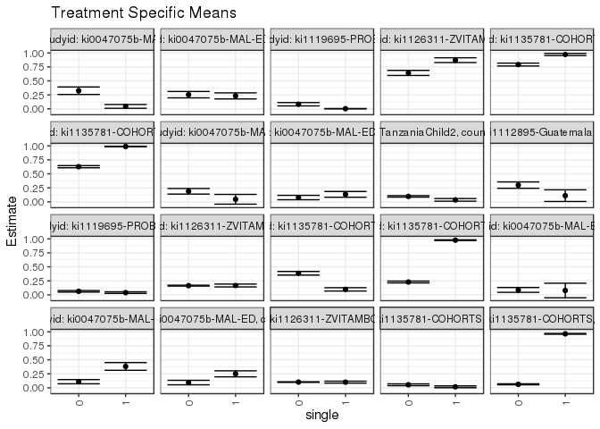

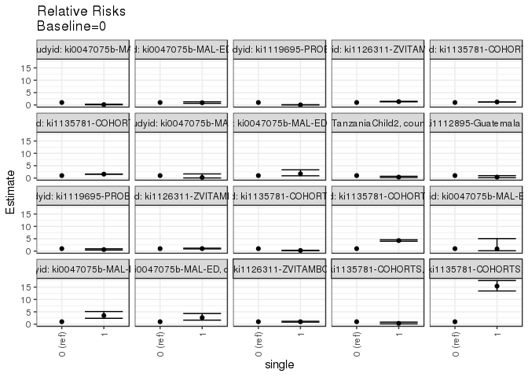

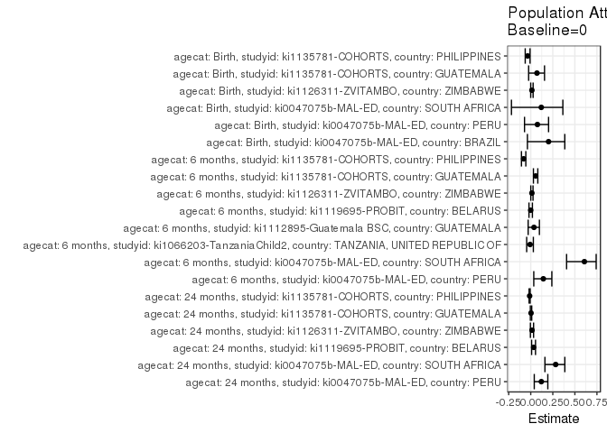

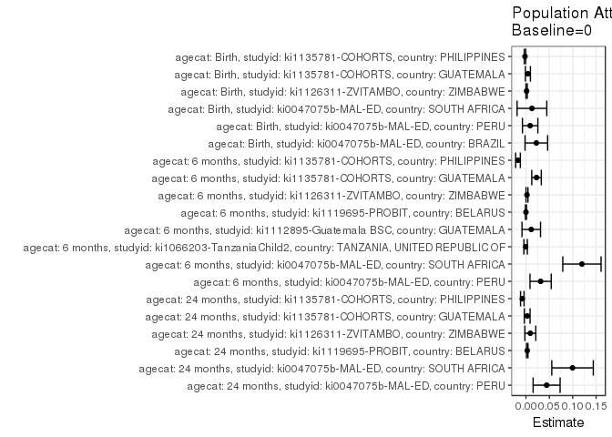

## Results Table

### Parameter: TSM

| agecat | studyid | country | intervention_level | baseline_level | estimate | ci_lower | ci_upper |
| --- | --- | --- | --- | --- | --- | --- | --- |
| Birth | ki0047075b-MAL-ED | BRAZIL | 0 | NA | 0.0877705 | 0.0442508 | 0.1312903 |
| Birth | ki0047075b-MAL-ED | BRAZIL | 1 | NA | 0.0777895 | -0.0520427 | 0.2076217 |
| Birth | ki0047075b-MAL-ED | PERU | 0 | NA | 0.1095023 | 0.0720187 | 0.1469859 |
| Birth | ki0047075b-MAL-ED | PERU | 1 | NA | 0.3822132 | 0.3134210 | 0.4510053 |
| Birth | ki0047075b-MAL-ED | SOUTH AFRICA | 0 | NA | 0.0941066 | 0.0536312 | 0.1345820 |
| Birth | ki0047075b-MAL-ED | SOUTH AFRICA | 1 | NA | 0.2498627 | 0.1959711 | 0.3037542 |
| Birth | ki1126311-ZVITAMBO | ZIMBABWE | 0 | NA | 0.1022397 | 0.0970281 | 0.1074513 |
| Birth | ki1126311-ZVITAMBO | ZIMBABWE | 1 | NA | 0.1012040 | 0.0835612 | 0.1188469 |
| Birth | ki1135781-COHORTS | GUATEMALA | 0 | NA | 0.0545388 | 0.0381118 | 0.0709658 |
| Birth | ki1135781-COHORTS | GUATEMALA | 1 | NA | 0.0180137 | 0.0021499 | 0.0338776 |
| Birth | ki1135781-COHORTS | PHILIPPINES | 0 | NA | 0.0625783 | 0.0540345 | 0.0711220 |
| Birth | ki1135781-COHORTS | PHILIPPINES | 1 | NA | 0.9635107 | 0.9569220 | 0.9700994 |
| 6 months | ki0047075b-MAL-ED | PERU | 0 | NA | 0.1884073 | 0.1383554 | 0.2384592 |
| 6 months | ki0047075b-MAL-ED | PERU | 1 | NA | 0.0458549 | -0.0415609 | 0.1332706 |
| 6 months | ki0047075b-MAL-ED | SOUTH AFRICA | 0 | NA | 0.0771677 | 0.0377942 | 0.1165411 |
| 6 months | ki0047075b-MAL-ED | SOUTH AFRICA | 1 | NA | 0.1338172 | 0.0829050 | 0.1847293 |
| 6 months | ki1066203-TanzaniaChild2 | TANZANIA, UNITED REPUBLIC OF | 0 | NA | 0.0976072 | 0.0840877 | 0.1111266 |
| 6 months | ki1066203-TanzaniaChild2 | TANZANIA, UNITED REPUBLIC OF | 1 | NA | 0.0350682 | 0.0116234 | 0.0585131 |
| 6 months | ki1112895-Guatemala BSC | GUATEMALA | 0 | NA | 0.2991276 | 0.2423282 | 0.3559269 |
| 6 months | ki1112895-Guatemala BSC | GUATEMALA | 1 | NA | 0.1108368 | 0.0063342 | 0.2153394 |
| 6 months | ki1119695-PROBIT | BELARUS | 0 | NA | 0.0627188 | 0.0486687 | 0.0767689 |
| 6 months | ki1119695-PROBIT | BELARUS | 1 | NA | 0.0393776 | 0.0251976 | 0.0535577 |
| 6 months | ki1126311-ZVITAMBO | ZIMBABWE | 0 | NA | 0.1640521 | 0.1558691 | 0.1722351 |
| 6 months | ki1126311-ZVITAMBO | ZIMBABWE | 1 | NA | 0.1668821 | 0.1416975 | 0.1920666 |
| 6 months | ki1135781-COHORTS | GUATEMALA | 0 | NA | 0.3850114 | 0.3525900 | 0.4174328 |
| 6 months | ki1135781-COHORTS | GUATEMALA | 1 | NA | 0.0974425 | 0.0677601 | 0.1271249 |
| 6 months | ki1135781-COHORTS | PHILIPPINES | 0 | NA | 0.2288868 | 0.2128671 | 0.2449065 |
| 6 months | ki1135781-COHORTS | PHILIPPINES | 1 | NA | 0.9761738 | 0.9702531 | 0.9820945 |
| 24 months | ki0047075b-MAL-ED | PERU | 0 | NA | 0.3239909 | 0.2570354 | 0.3909464 |
| 24 months | ki0047075b-MAL-ED | PERU | 1 | NA | 0.0442133 | 0.0101976 | 0.0782290 |
| 24 months | ki0047075b-MAL-ED | SOUTH AFRICA | 0 | NA | 0.2533169 | 0.1965467 | 0.3100871 |
| 24 months | ki0047075b-MAL-ED | SOUTH AFRICA | 1 | NA | 0.2316768 | 0.1774337 | 0.2859198 |
| 24 months | ki1119695-PROBIT | BELARUS | 0 | NA | 0.0825105 | 0.0526121 | 0.1124089 |
| 24 months | ki1119695-PROBIT | BELARUS | 1 | NA | 0.0033507 | 0.0013633 | 0.0053380 |
| 24 months | ki1126311-ZVITAMBO | ZIMBABWE | 0 | NA | 0.6419688 | 0.5965996 | 0.6873379 |
| 24 months | ki1126311-ZVITAMBO | ZIMBABWE | 1 | NA | 0.8698308 | 0.8273687 | 0.9122929 |
| 24 months | ki1135781-COHORTS | GUATEMALA | 0 | NA | 0.7910668 | 0.7657637 | 0.8163700 |
| 24 months | ki1135781-COHORTS | GUATEMALA | 1 | NA | 0.9707686 | 0.9515697 | 0.9899675 |
| 24 months | ki1135781-COHORTS | PHILIPPINES | 0 | NA | 0.6274638 | 0.6081061 | 0.6468215 |
| 24 months | ki1135781-COHORTS | PHILIPPINES | 1 | NA | 0.9885720 | 0.9840334 | 0.9931105 |

### Parameter: E(Y)

| agecat | studyid | country | intervention_level | baseline_level | estimate | ci_lower | ci_upper |
| --- | --- | --- | --- | --- | --- | --- | --- |
| Birth | ki0047075b-MAL-ED | BRAZIL | NA | NA | 0.1099476 | 0.0654669 | 0.1544284 |
| Birth | ki0047075b-MAL-ED | PERU | NA | NA | 0.1184669 | 0.0810142 | 0.1559196 |
| Birth | ki0047075b-MAL-ED | SOUTH AFRICA | NA | NA | 0.1068702 | 0.0693890 | 0.1443514 |
| Birth | ki1126311-ZVITAMBO | ZIMBABWE | NA | NA | 0.1036160 | 0.0985259 | 0.1087061 |
| Birth | ki1135781-COHORTS | GUATEMALA | NA | NA | 0.0586701 | 0.0420278 | 0.0753124 |
| Birth | ki1135781-COHORTS | PHILIPPINES | NA | NA | 0.0604651 | 0.0519489 | 0.0689813 |
| 6 months | ki0047075b-MAL-ED | PERU | NA | NA | 0.2197802 | 0.1705687 | 0.2689917 |
| 6 months | ki0047075b-MAL-ED | SOUTH AFRICA | NA | NA | 0.1968504 | 0.1478551 | 0.2458457 |
| 6 months | ki1066203-TanzaniaChild2 | TANZANIA, UNITED REPUBLIC OF | NA | NA | 0.0968703 | 0.0839461 | 0.1097946 |
| 6 months | ki1112895-Guatemala BSC | GUATEMALA | NA | NA | 0.3104693 | 0.2558835 | 0.3650551 |
| 6 months | ki1119695-PROBIT | BELARUS | NA | NA | 0.0626864 | 0.0488489 | 0.0765239 |
| 6 months | ki1126311-ZVITAMBO | ZIMBABWE | NA | NA | 0.1662432 | 0.1582164 | 0.1742700 |
| 6 months | ki1135781-COHORTS | GUATEMALA | NA | NA | 0.4076148 | 0.3753675 | 0.4398620 |
| 6 months | ki1135781-COHORTS | PHILIPPINES | NA | NA | 0.2118834 | 0.1963977 | 0.2273691 |
| 24 months | ki0047075b-MAL-ED | PERU | NA | NA | 0.3681592 | 0.3013164 | 0.4350020 |
| 24 months | ki0047075b-MAL-ED | SOUTH AFRICA | NA | NA | 0.3529412 | 0.2921001 | 0.4137823 |
| 24 months | ki1119695-PROBIT | BELARUS | NA | NA | 0.0852540 | 0.0554439 | 0.1150642 |
| 24 months | ki1126311-ZVITAMBO | ZIMBABWE | NA | NA | 0.6513158 | 0.6075279 | 0.6951037 |
| 24 months | ki1135781-COHORTS | GUATEMALA | NA | NA | 0.7936821 | 0.7687506 | 0.8186137 |
| 24 months | ki1135781-COHORTS | PHILIPPINES | NA | NA | 0.6196192 | 0.6002567 | 0.6389817 |

### Parameter: RR

| agecat | studyid | country | intervention_level | baseline_level | estimate | ci_lower | ci_upper |
| --- | --- | --- | --- | --- | --- | --- | --- |
| Birth | ki0047075b-MAL-ED | BRAZIL | 0 | 0 | 1.0000000 | 1.0000000 | 1.0000000 |
| Birth | ki0047075b-MAL-ED | BRAZIL | 1 | 0 | 0.8862825 | 0.1552490 | 5.0595931 |
| Birth | ki0047075b-MAL-ED | PERU | 0 | 0 | 1.0000000 | 1.0000000 | 1.0000000 |
| Birth | ki0047075b-MAL-ED | PERU | 1 | 0 | 3.4904578 | 2.3788468 | 5.1215133 |
| Birth | ki0047075b-MAL-ED | SOUTH AFRICA | 0 | 0 | 1.0000000 | 1.0000000 | 1.0000000 |
| Birth | ki0047075b-MAL-ED | SOUTH AFRICA | 1 | 0 | 2.6551021 | 1.6361528 | 4.3086242 |
| Birth | ki1126311-ZVITAMBO | ZIMBABWE | 0 | 0 | 1.0000000 | 1.0000000 | 1.0000000 |
| Birth | ki1126311-ZVITAMBO | ZIMBABWE | 1 | 0 | 0.9898705 | 0.8256948 | 1.1866899 |
| Birth | ki1135781-COHORTS | GUATEMALA | 0 | 0 | 1.0000000 | 1.0000000 | 1.0000000 |
| Birth | ki1135781-COHORTS | GUATEMALA | 1 | 0 | 0.3302919 | 0.1312296 | 0.8313115 |
| Birth | ki1135781-COHORTS | PHILIPPINES | 0 | 0 | 1.0000000 | 1.0000000 | 1.0000000 |
| Birth | ki1135781-COHORTS | PHILIPPINES | 1 | 0 | 15.3968882 | 13.4260682 | 17.6570059 |
| 6 months | ki0047075b-MAL-ED | PERU | 0 | 0 | 1.0000000 | 1.0000000 | 1.0000000 |
| 6 months | ki0047075b-MAL-ED | PERU | 1 | 0 | 0.2433816 | 0.0354402 | 1.6713942 |
| 6 months | ki0047075b-MAL-ED | SOUTH AFRICA | 0 | 0 | 1.0000000 | 1.0000000 | 1.0000000 |
| 6 months | ki0047075b-MAL-ED | SOUTH AFRICA | 1 | 0 | 1.7341088 | 0.9001732 | 3.3406164 |
| 6 months | ki1066203-TanzaniaChild2 | TANZANIA, UNITED REPUBLIC OF | 0 | 0 | 1.0000000 | 1.0000000 | 1.0000000 |
| 6 months | ki1066203-TanzaniaChild2 | TANZANIA, UNITED REPUBLIC OF | 1 | 0 | 0.3592792 | 0.1815203 | 0.7111136 |
| 6 months | ki1112895-Guatemala BSC | GUATEMALA | 0 | 0 | 1.0000000 | 1.0000000 | 1.0000000 |
| 6 months | ki1112895-Guatemala BSC | GUATEMALA | 1 | 0 | 0.3705335 | 0.1417160 | 0.9688047 |
| 6 months | ki1119695-PROBIT | BELARUS | 0 | 0 | 1.0000000 | 1.0000000 | 1.0000000 |
| 6 months | ki1119695-PROBIT | BELARUS | 1 | 0 | 0.6278441 | 0.4254142 | 0.9265986 |
| 6 months | ki1126311-ZVITAMBO | ZIMBABWE | 0 | 0 | 1.0000000 | 1.0000000 | 1.0000000 |
| 6 months | ki1126311-ZVITAMBO | ZIMBABWE | 1 | 0 | 1.0172504 | 0.8682058 | 1.1918814 |
| 6 months | ki1135781-COHORTS | GUATEMALA | 0 | 0 | 1.0000000 | 1.0000000 | 1.0000000 |
| 6 months | ki1135781-COHORTS | GUATEMALA | 1 | 0 | 0.2530899 | 0.1847949 | 0.3466247 |
| 6 months | ki1135781-COHORTS | PHILIPPINES | 0 | 0 | 1.0000000 | 1.0000000 | 1.0000000 |
| 6 months | ki1135781-COHORTS | PHILIPPINES | 1 | 0 | 4.2648759 | 3.9706916 | 4.5808561 |
| 24 months | ki0047075b-MAL-ED | PERU | 0 | 0 | 1.0000000 | 1.0000000 | 1.0000000 |
| 24 months | ki0047075b-MAL-ED | PERU | 1 | 0 | 0.1364647 | 0.0600798 | 0.3099644 |
| 24 months | ki0047075b-MAL-ED | SOUTH AFRICA | 0 | 0 | 1.0000000 | 1.0000000 | 1.0000000 |
| 24 months | ki0047075b-MAL-ED | SOUTH AFRICA | 1 | 0 | 0.9145728 | 0.6556654 | 1.2757168 |
| 24 months | ki1119695-PROBIT | BELARUS | 0 | 0 | 1.0000000 | 1.0000000 | 1.0000000 |
| 24 months | ki1119695-PROBIT | BELARUS | 1 | 0 | 0.0406091 | 0.0207325 | 0.0795416 |
| 24 months | ki1126311-ZVITAMBO | ZIMBABWE | 0 | 0 | 1.0000000 | 1.0000000 | 1.0000000 |
| 24 months | ki1126311-ZVITAMBO | ZIMBABWE | 1 | 0 | 1.3549426 | 1.2464962 | 1.4728239 |
| 24 months | ki1135781-COHORTS | GUATEMALA | 0 | 0 | 1.0000000 | 1.0000000 | 1.0000000 |
| 24 months | ki1135781-COHORTS | GUATEMALA | 1 | 0 | 1.2271638 | 1.1820316 | 1.2740192 |
| 24 months | ki1135781-COHORTS | PHILIPPINES | 0 | 0 | 1.0000000 | 1.0000000 | 1.0000000 |
| 24 months | ki1135781-COHORTS | PHILIPPINES | 1 | 0 | 1.5755043 | 1.5267945 | 1.6257681 |

### Parameter: PAR

| agecat | studyid | country | intervention_level | baseline_level | estimate | ci_lower | ci_upper |
| --- | --- | --- | --- | --- | --- | --- | --- |
| Birth | ki0047075b-MAL-ED | BRAZIL | 0 | NA | 0.0221771 | -0.0019979 | 0.0463522 |
| Birth | ki0047075b-MAL-ED | PERU | 0 | NA | 0.0089646 | -0.0074997 | 0.0254289 |
| Birth | ki0047075b-MAL-ED | SOUTH AFRICA | 0 | NA | 0.0127636 | -0.0189747 | 0.0445019 |
| Birth | ki1126311-ZVITAMBO | ZIMBABWE | 0 | NA | 0.0013764 | -0.0000458 | 0.0027985 |
| Birth | ki1135781-COHORTS | GUATEMALA | 0 | NA | 0.0041313 | -0.0012483 | 0.0095109 |
| Birth | ki1135781-COHORTS | PHILIPPINES | 0 | NA | -0.0021132 | -0.0037169 | -0.0005094 |
| 6 months | ki0047075b-MAL-ED | PERU | 0 | NA | 0.0313730 | 0.0086600 | 0.0540859 |
| 6 months | ki0047075b-MAL-ED | SOUTH AFRICA | 0 | NA | 0.1196827 | 0.0787349 | 0.1606305 |
| 6 months | ki1066203-TanzaniaChild2 | TANZANIA, UNITED REPUBLIC OF | 0 | NA | -0.0007368 | -0.0043972 | 0.0029235 |
| 6 months | ki1112895-Guatemala BSC | GUATEMALA | 0 | NA | 0.0113418 | -0.0084690 | 0.0311525 |
| 6 months | ki1119695-PROBIT | BELARUS | 0 | NA | -0.0000324 | -0.0012516 | 0.0011867 |
| 6 months | ki1126311-ZVITAMBO | ZIMBABWE | 0 | NA | 0.0021911 | 0.0000800 | 0.0043022 |
| 6 months | ki1135781-COHORTS | GUATEMALA | 0 | NA | 0.0226034 | 0.0124063 | 0.0328005 |
| 6 months | ki1135781-COHORTS | PHILIPPINES | 0 | NA | -0.0170034 | -0.0220119 | -0.0119949 |
| 24 months | ki0047075b-MAL-ED | PERU | 0 | NA | 0.0441683 | 0.0153353 | 0.0730013 |
| 24 months | ki0047075b-MAL-ED | SOUTH AFRICA | 0 | NA | 0.0996242 | 0.0552638 | 0.1439846 |
| 24 months | ki1119695-PROBIT | BELARUS | 0 | NA | 0.0027435 | 0.0011612 | 0.0043259 |
| 24 months | ki1126311-ZVITAMBO | ZIMBABWE | 0 | NA | 0.0093470 | -0.0023199 | 0.0210140 |
| 24 months | ki1135781-COHORTS | GUATEMALA | 0 | NA | 0.0026153 | -0.0035600 | 0.0087906 |
| 24 months | ki1135781-COHORTS | PHILIPPINES | 0 | NA | -0.0078446 | -0.0115868 | -0.0041024 |

### Parameter: PAF

| agecat | studyid | country | intervention_level | baseline_level | estimate | ci_lower | ci_upper |
| --- | --- | --- | --- | --- | --- | --- | --- |
| Birth | ki0047075b-MAL-ED | BRAZIL | 0 | NA | 0.2017061 | -0.0377070 | 0.3858834 |
| Birth | ki0047075b-MAL-ED | PERU | 0 | NA | 0.0756718 | -0.0705963 | 0.2019562 |
| Birth | ki0047075b-MAL-ED | SOUTH AFRICA | 0 | NA | 0.1194310 | -0.2186305 | 0.3637106 |
| Birth | ki1126311-ZVITAMBO | ZIMBABWE | 0 | NA | 0.0132832 | -0.0005180 | 0.0268940 |
| Birth | ki1135781-COHORTS | GUATEMALA | 0 | NA | 0.0704159 | -0.0238932 | 0.1560384 |
| Birth | ki1135781-COHORTS | PHILIPPINES | 0 | NA | -0.0349484 | -0.0626598 | -0.0079596 |
| 6 months | ki0047075b-MAL-ED | PERU | 0 | NA | 0.1427470 | 0.0343225 | 0.2389977 |
| 6 months | ki0047075b-MAL-ED | SOUTH AFRICA | 0 | NA | 0.6079882 | 0.4060937 | 0.7412500 |
| 6 months | ki1066203-TanzaniaChild2 | TANZANIA, UNITED REPUBLIC OF | 0 | NA | -0.0076063 | -0.0460983 | 0.0294692 |
| 6 months | ki1112895-Guatemala BSC | GUATEMALA | 0 | NA | 0.0365310 | -0.0293208 | 0.0981699 |
| 6 months | ki1119695-PROBIT | BELARUS | 0 | NA | -0.0005175 | -0.0201411 | 0.0187285 |
| 6 months | ki1126311-ZVITAMBO | ZIMBABWE | 0 | NA | 0.0131801 | 0.0004199 | 0.0257774 |
| 6 months | ki1135781-COHORTS | GUATEMALA | 0 | NA | 0.0554529 | 0.0303432 | 0.0799123 |
| 6 months | ki1135781-COHORTS | PHILIPPINES | 0 | NA | -0.0802488 | -0.1051885 | -0.0558719 |
| 24 months | ki0047075b-MAL-ED | PERU | 0 | NA | 0.1199707 | 0.0398109 | 0.1934386 |
| 24 months | ki0047075b-MAL-ED | SOUTH AFRICA | 0 | NA | 0.2822687 | 0.1606558 | 0.3862610 |
| 24 months | ki1119695-PROBIT | BELARUS | 0 | NA | 0.0321807 | 0.0099438 | 0.0539182 |
| 24 months | ki1126311-ZVITAMBO | ZIMBABWE | 0 | NA | 0.0143510 | -0.0037568 | 0.0321321 |
| 24 months | ki1135781-COHORTS | GUATEMALA | 0 | NA | 0.0032951 | -0.0045100 | 0.0110396 |
| 24 months | ki1135781-COHORTS | PHILIPPINES | 0 | NA | -0.0126604 | -0.0187697 | -0.0065877 |